# Exercício: SARIMA no comércio varejista brasileiro

UF: Santa Catarina

Autor

Daniel Bauer

## Sobre o exercício

Base: PMC (Pesquisa Mensal do Comércio) do IBGE, índice de volume de vendas no comércio varejista ampliado, mensal desde jan/2004, base 2022 = 100, sem ajuste sazonal. UF escolhida: **Santa Catarina**.

## Setup

```python
import numpy as np
import pandas as pd
import matplotlib.pyplot as plt

from statsmodels.tsa.stattools import adfuller, kpss
from statsmodels.graphics.tsaplots import plot_acf, plot_pacf
from statsmodels.stats.diagnostic import acorr_ljungbox

from statsforecast import StatsForecast
from statsforecast.models import AutoARIMA
from statsforecast.arima import ndiffs, nsdiffs, arima_string
```

## Carregando a base PMC

```python
pmc = pd.read_csv("https://github.com/padsInsper/202634-fa/releases/download/data/pmc_volume_uf.csv")
pmc["data"] = pd.to_datetime(pmc["data"])
```

## Escolha sua UF

```python
MINHA_UF = "Santa Catarina"

df_sf = (
    pmc.query("uf == @MINHA_UF")
    .rename(columns={"uf": "unique_id", "data": "ds", "volume_idx": "y"})
    [["unique_id", "ds", "y"]]
    .reset_index(drop=True)
)

y = df_sf.set_index("ds")["y"]
print(len(y), "meses, de", y.index.min().date(), "a", y.index.max().date())
df_sf.head()
```

```
266 meses, de 2004-01-01 a 2026-02-01
```

|  | unique_id | ds | y |
| --- | --- | --- | --- |
| 0 | Santa Catarina | 2004-01-01 | 35.97412 |
| 1 | Santa Catarina | 2004-02-01 | 34.59050 |
| 2 | Santa Catarina | 2004-03-01 | 38.74136 |
| 3 | Santa Catarina | 2004-04-01 | 37.91118 |
| 4 | Santa Catarina | 2004-05-01 | 38.60299 |

## Análise descritiva

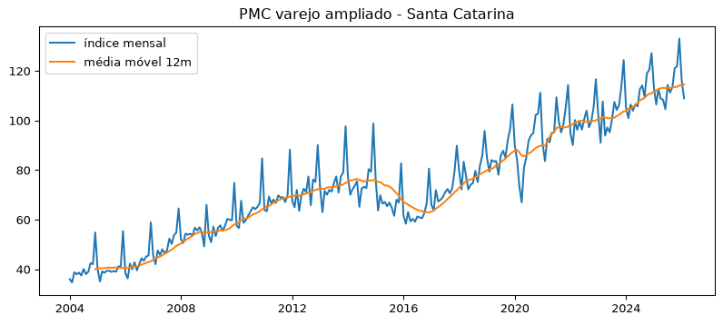

```python
fig, ax = plt.subplots(figsize=(10, 4))
ax.plot(y, label="índice mensal")
ax.plot(y.rolling(12).mean(), label="média móvel 12m")
ax.set_title("PMC varejo ampliado - Santa Catarina")
ax.legend()
plt.show()
```

A série tem tendência de alta clara (forte até 2014, queda em 2015-2016, volta a subir a partir de 2017, tombo em abril/2020 e recuperação). Por cima disso tem um padrão anual bem marcado, com pico todo dezembro.

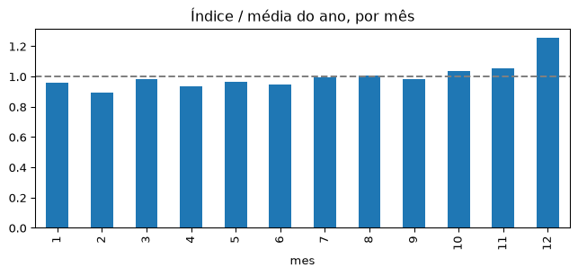

```python
# média de cada mês, normalizada pela média do ano
aux = df_sf.assign(ano=df_sf.ds.dt.year, mes=df_sf.ds.dt.month)
aux["rel"] = aux.y / aux.groupby("ano").y.transform("mean")
aux.query("ano < 2026").groupby("mes").rel.mean().plot(kind="bar", figsize=(8, 3), title="Índice / média do ano, por mês")
plt.axhline(1, color="gray", ls="--")
plt.show()
```

### ACF e PACF

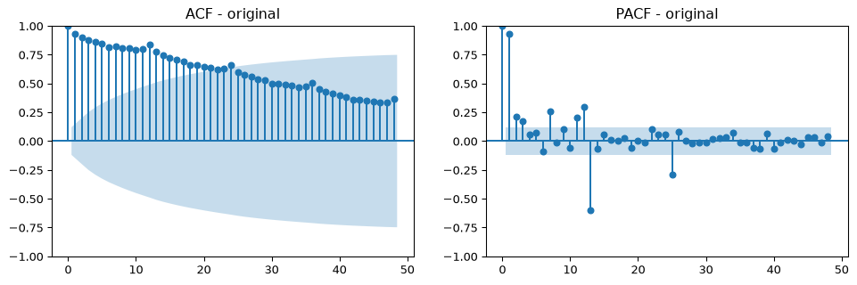

```python
def acf_pacf(serie, titulo):
    fig, ax = plt.subplots(1, 2, figsize=(12, 3.5))
    plot_acf(serie.dropna(), lags=48, ax=ax[0], title=f"ACF - {titulo}")
    plot_pacf(serie.dropna(), lags=48, ax=ax[1], title=f"PACF - {titulo}")
    plt.show()

acf_pacf(y, "original")
```

ACF decaindo bem devagar (tendência / não estacionária) e com picos nos lags 12, 24, 36 (sazonalidade). PACF com lag 1 quase em 1.

### Diferenciação

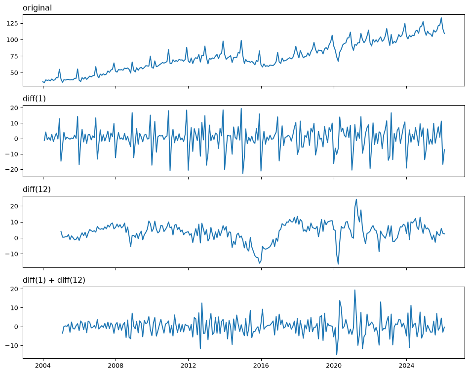

```python
difs = {
    "original": y,
    "diff(1)": y.diff(),
    "diff(12)": y.diff(12),
    "diff(1) + diff(12)": y.diff().diff(12),
}

fig, axes = plt.subplots(4, 1, figsize=(10, 8), sharex=True)
for ax, (nome, s) in zip(axes, difs.items()):
    ax.plot(s)
    ax.set_title(nome, loc="left")
plt.tight_layout()
plt.show()
```

- `diff(1)` tira a tendência, mas o serrote anual continua.
- `diff(12)` tira a sazonalidade e sobra a variação contra o mesmo mês do ano anterior, que oscila acima de zero (crescimento médio).
- `diff(1) + diff(12)` fica centrada em zero.

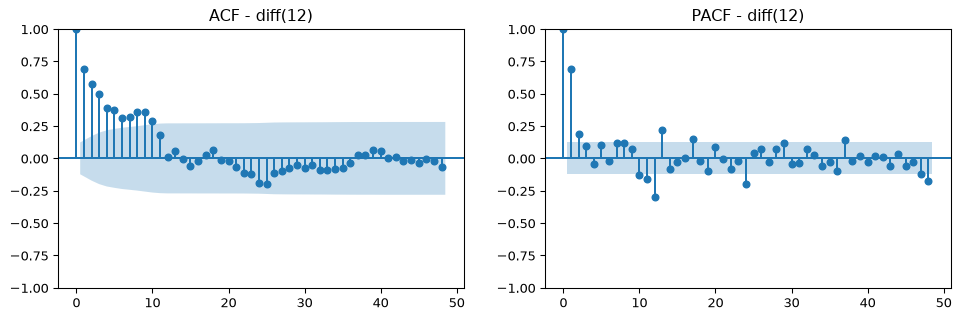

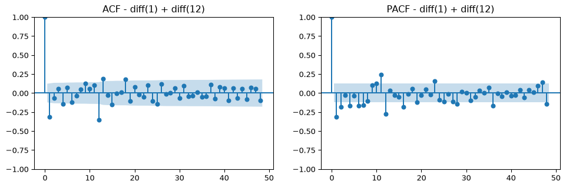

```python
acf_pacf(y.diff(12), "diff(12)")
acf_pacf(y.diff().diff(12), "diff(1) + diff(12)")
```

## Testes de raiz unitária

ADF: H0 = tem raiz unitária. KPSS: H0 = é estacionária. Queremos ADF com p < 0,05 e KPSS com p > 0,05.

```python
linhas = []
for nome, s in difs.items():
    s = s.dropna()
    p_adf = adfuller(s, autolag="AIC")[1]
    p_kpss = kpss(s, regression="c", nlags="auto")[1]
    linhas.append({"série": nome, "ADF p-valor": round(p_adf, 4), "KPSS p-valor": round(p_kpss, 4)})
pd.DataFrame(linhas)
```

|  | série | ADF p-valor | KPSS p-valor |
| --- | --- | --- | --- |
| 0 | original | 0.9494 | 0.01 |
| 1 | diff(1) | 0.0001 | 0.10 |
| 2 | diff(12) | 0.0105 | 0.10 |
| 3 | diff(1) + diff(12) | 0.0000 | 0.10 |

(o KPSS do statsmodels trava o p-valor entre 0,01 e 0,10)

Original: não estacionária nos dois testes. Qualquer uma das diferenças já resolve, inclusive só a sazonal.

```python
print("nsdiffs (sazonal):", nsdiffs(y.values, period=12))
print("ndiffs na série original:", ndiffs(y.values))
print("ndiffs depois da diff(12):", ndiffs(y.diff(12).dropna().values))
```

```
nsdiffs (sazonal): 1
ndiffs na série original: 1
ndiffs depois da diff(12): 0
```

O `ndiffs` na série original dá 1, mas depois de tirar a diferença sazonal dá 0. Como o AutoARIMA decide primeiro a parte sazonal e depois a regular, a expectativa é D = 1 e d = 0.

## Modelagem

```python
sf = StatsForecast(models=[AutoARIMA(season_length=12)], freq="MS")
sf.fit(df_sf)

modelo = sf.fitted_[0, 0].model_
print(arima_string(modelo))
print({k: round(float(v), 3) for k, v in modelo["coef"].items()})
print("AICc:", round(modelo["aicc"], 1), "| sigma:", round(np.sqrt(modelo["sigma2"]), 2))
```

```
ARIMA(2,0,1)(1,1,1)[12] with drift
{'ar1': 1.335, 'ar2': -0.356, 'ma1': -0.728, 'sar1': 0.185, 'sma1': -0.858, 'drift': 0.293}
AICc: 1360.9 | sigma: 3.38
```

Modelo escolhido: **ARIMA(2,0,1)(1,1,1)[12] com drift**.

- D = 1 e d = 0, como os testes indicaram. O drift faz o papel da tendência (crescimento médio ano contra ano).
- AR(2) com ar1 + ar2 perto de 1: a variação anual é bem persistente (ciclo econômico).
- SMA(1) perto de -0,86: sazonalidade quase fixa, bate com o pico negativo no lag 12 da ACF.

## Diagnóstico dos resíduos

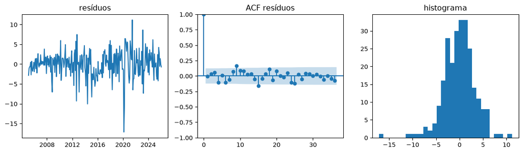

|  | lb_stat | lb_pvalue |
| --- | --- | --- |
| 12 | 20.279389 | 0.002469 |
| 24 | 39.395533 | 0.002521 |

```python
res = pd.Series(modelo["residuals"], index=y.index).iloc[13:]  # descarta o início (diferença sazonal)

fig, ax = plt.subplots(1, 3, figsize=(14, 3.5))
ax[0].plot(res); ax[0].set_title("resíduos")
plot_acf(res, lags=36, ax=ax[1], title="ACF resíduos")
ax[2].hist(res, bins=30); ax[2].set_title("histograma")
plt.show()

acorr_ljungbox(res, lags=[12, 24], model_df=len(modelo["coef"]))
```

```python
res.abs().sort_values(ascending=False).head(5)
```

```
ds
2020-03-01    17.152471
2021-07-01    11.158476
2020-04-01    10.916067
2014-06-01    10.056073
2012-09-01     9.325005
dtype: float64
```

A ACF não mostra mais pico sazonal (lags 12, 24, 36 ok), mas o Ljung-Box rejeita ruído branco (p < 0,01). Os maiores resíduos são mar-abr/2020 (início da pandemia), jul/2021 (reabertura), jun/2014 (Copa do Mundo) e set/2012. O histograma tem cauda mais longa para a esquerda, ou seja, as surpresas grandes são quedas.

## Previsão · 24 meses à frente

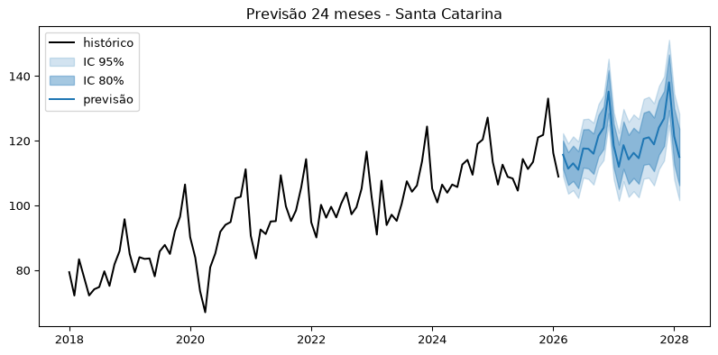

```python
prev = sf.predict(h=24, level=[80, 95])

fig, ax = plt.subplots(figsize=(10, 4.5))
ax.plot(y["2018":], color="black", label="histórico")
ax.fill_between(prev.ds, prev["AutoARIMA-lo-95"], prev["AutoARIMA-hi-95"], alpha=0.2, color="C0", label="IC 95%")
ax.fill_between(prev.ds, prev["AutoARIMA-lo-80"], prev["AutoARIMA-hi-80"], alpha=0.4, color="C0", label="IC 80%")
ax.plot(prev.ds, prev["AutoARIMA"], color="C0", label="previsão")
ax.set_title("Previsão 24 meses - Santa Catarina")
ax.legend(loc="upper left")
plt.show()
```

```python
prev[["ds", "AutoARIMA", "AutoARIMA-lo-95", "AutoARIMA-hi-95"]].iloc[[0, 5, 11, 17, 23]].round(1)
```

|  | ds | AutoARIMA | AutoARIMA-lo-95 | AutoARIMA-hi-95 |
| --- | --- | --- | --- | --- |
| 0 | 2026-03-01 | 115.7 | 109.0 | 122.3 |
| 5 | 2026-08-01 | 117.5 | 108.2 | 126.8 |
| 11 | 2027-02-01 | 111.9 | 101.4 | 122.4 |
| 17 | 2027-08-01 | 121.0 | 108.5 | 133.5 |
| 23 | 2028-02-01 | 115.0 | 101.6 | 128.3 |

## Discussão

**1. O ACF/PACF da série original sugeriu sazonalidade? E tendência? Bate com o gráfico de linha?**

Sim, mostrou as duas coisas. As barras do ACF vão diminuindo bem devagar, o que indica que a série vem subindo ao longo dos anos (tendência). Além disso, aparecem picos de 12 em 12 meses, o que mostra que um mês se parece com o mesmo mês do ano anterior (sazonalidade). Isso bate com o gráfico de linha: as vendas em SC crescem bastante desde 2004 e todo ano tem um pico em dezembro, por causa do Natal e do 13º.

**2. Quantas diferenças o AutoARIMA aplicou? E os componentes AR/MA? Deu para ver no ACF/PACF?**

O modelo escolhido foi o ARIMA(2,0,1)(1,1,1)[12] com drift. Ele aplicou só uma diferença, a sazonal (comparar cada mês com o mesmo mês do ano anterior), e nenhuma diferença mês a mês. Isso faz sentido porque os testes ADF e KPSS já mostraram que só a diferença sazonal deixa a série estável. A tendência de alta ficou por conta do drift, que é um crescimento médio por ano. Nos gráficos deu para ver uma parte disso: o pico negativo no lag 12 depois da diferença sazonal indica o termo MA sazonal, e as primeiras barras ainda altas mostram que um mês bom costuma ser seguido de outro mês bom, que é o que o AR captura. O número exato de termos eu não conseguiria acertar só olhando os gráficos, e por isso usei o AutoARIMA.

**3. Os resíduos parecem white noise? Algum padrão sazonal remanescente?**

Em boa parte, sim. No ACF dos resíduos não sobrou pico nos lags 12, 24 e 36, então o padrão de dezembro foi bem capturado pelo modelo. Mesmo assim, o teste de Ljung-Box deu p-valor abaixo de 0,05, ou seja, ainda sobra um pouco de padrão nos erros. Olhando os maiores erros, eles estão em março e abril de 2020 (começo da pandemia), julho de 2021 (reabertura) e junho de 2014 (Copa do Mundo). São eventos que nenhum modelo baseado só no passado conseguiria prever. Uma melhoria seria incluir uma variável indicando o período da pandemia.

**4. A previsão pareceu razoável visualmente?**

Sim. A previsão continua com o mesmo desenho dos anos anteriores, com pico em dezembro e queda em fevereiro, e começa no nível em que a série parou. Os intervalos de 80% e 95% vão ficando mais largos com o tempo, o que é esperado: prever o próximo mês é mais fácil do que prever daqui a dois anos. O ponto fraco é que o modelo supõe que o crescimento continua no mesmo ritmo, então não prevê uma crise ou uma desaceleração da economia.

**5. Que outras UFs dariam um SARIMA bem diferente do seu (e por quê)?**

Estados do Norte, como Roraima e Amapá, devem dar modelos bem diferentes. As vendas lá cresceram muito mais rápido que em SC e a série é mais instável, porque a economia é menor e qualquer mudança pesa mais. Estados agrícolas como Mato Grosso e Goiás também devem mudar, porque a venda de veículos e máquinas depende da safra e do crédito rural, e isso cria picos em outros meses além de dezembro. Já Rio de Janeiro e Distrito Federal cresceram pouco nos últimos anos e sentiram mais as crises, então a tendência seria mais fraca. Santa Catarina tem um crescimento forte e constante e um padrão anual bem regular, o que deixa a série mais fácil de modelar.